# Objective

### Q6. Budget phones nowadays offer great selfie cameras, allowing us to capture our favorite moments with loved ones.

- What is the distribution of budget phones offering greater than 8MP selfie cameras across brands?

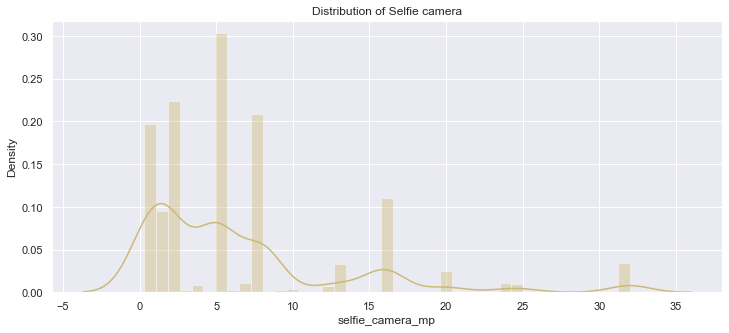

```python
# Let's plot distribution to analyze
plt.figure(figsize = (12,5))
plt.title('Distribution of Selfie camera')
d_selfie = mobData[mobData['selfie_camera_mp']>8]
sns.distplot(mobData['selfie_camera_mp'], color = 'y')
```

```python
d_selfie.groupby('brand_name')['selfie_camera_mp'].count()
d_selfie.sort_values(by='selfie_camera_mp')
```

|  | brand_name | os | screen_size | fourG | fiveG | main_camera_mp | selfie_camera_mp | int_memory | ram | battery | weight | release_year | days_used | new_price | used_price |
| --- | --- | --- | --- | --- | --- | --- | --- | --- | --- | --- | --- | --- | --- | --- | --- |
| 2449 | Samsung | Others | 6.86 | no | no | 12.00 | 9.00 | 16.00 | 4.00 | 230.00 | 25.00 | 2019 | 337 | 251.64 | 163.10 |
| 2445 | Samsung | Android | 40.34 | yes | no | 12.00 | 9.00 | 1024.00 | 4.00 | 4100.00 | 175.00 | 2019 | 291 | 1050.76 | 726.73 |
| 3552 | Samsung | Android | 46.38 | yes | yes | 12.00 | 9.00 | 512.00 | 12.00 | 4235.00 | 263.00 | 2019 | 434 | 1529.99 | 765.02 |
| 2454 | Samsung | Android | 41.53 | yes | no | 12.00 | 9.00 | 128.00 | 4.00 | 3700.00 | 169.00 | 2019 | 291 | 650.76 | 453.34 |
| 3558 | Samsung | Others | 8.08 | yes | no | 12.00 | 9.00 | 4.00 | 1.50 | 340.00 | 42.00 | 2019 | 524 | 240.64 | 120.38 |
| ... | ... | ... | ... | ... | ... | ... | ... | ... | ... | ... | ... | ... | ... | ... | ... |
| 3427 | Xiaomi | Android | 57.66 | yes | no | 12.00 | 32.00 | 128.00 | 6.00 | 5260.00 | 208.00 | 2019 | 207 | 390.99 | 290.74 |
| 3426 | Xiaomi | Android | 57.66 | yes | no | 12.00 | 32.00 | 128.00 | 6.00 | 5260.00 | 208.00 | 2019 | 391 | 280.49 | 184.46 |
| 3425 | Xiaomi | Android | 57.66 | yes | no | 12.00 | 32.00 | 256.00 | 8.00 | 5260.00 | 208.00 | 2019 | 355 | 559.55 | 365.31 |
| 3456 | Honor | Android | 47.17 | yes | no | 13.00 | 32.00 | 128.00 | 4.00 | 3400.00 | 164.00 | 2019 | 355 | 137.70 | 88.04 |
| 1140 | Honor | Android | 47.17 | yes | no | 13.00 | 32.00 | 128.00 | 4.00 | 3400.00 | 164.00 | 2019 | 289 | 279.89 | 190.38 |

666 rows × 15 columns

```python
d_selfie_brand=d_selfie.groupby("brand_name")["selfie_camera_mp"]
d_selfie_brand.count().sort_values(ascending=False)
```

```
brand_name
Huawei        91
Vivo          78
Oppo          75
Xiaomi        65
Samsung       60
Honor         43
Others        34
LG            32
Motorola      26
Meizu         24
ZTE           20
HTC           20
Realme        18
OnePlus       18
Sony          14
Lenovo        14
Nokia         10
Asus           6
Gionee         4
Infinix        4
Coolpad        3
Micromax       2
Panasonic      2
BlackBerry     2
Acer           1
Apple          0
XOLO           0
Spice          0
Google         0
Karbonn        0
Lava           0
Microsoft      0
Alcatel        0
Celkon         0
Name: selfie_camera_mp, dtype: int64
```

```python
d_selfie.describe().T
```

|  | count | mean | std | min | 25% | 50% | 75% | max |
| --- | --- | --- | --- | --- | --- | --- | --- | --- |
| screen_size | 666.00 | 46.57 | 11.67 | 6.86 | 39.52 | 40.92 | 55.96 | 82.27 |
| main_camera_mp | 666.00 | 11.39 | 4.30 | 0.30 | 8.00 | 12.00 | 13.00 | 48.00 |
| selfie_camera_mp | 666.00 | 18.68 | 6.31 | 9.00 | 16.00 | 16.00 | 20.00 | 32.00 |
| int_memory | 666.00 | 108.24 | 83.03 | 4.00 | 64.00 | 128.00 | 128.00 | 1024.00 |
| ram | 666.00 | 5.27 | 2.09 | 0.03 | 4.00 | 4.00 | 6.00 | 16.00 |
| battery | 666.00 | 3828.56 | 776.01 | 230.00 | 3400.00 | 4000.00 | 4200.00 | 6000.00 |
| weight | 666.00 | 180.39 | 28.71 | 25.00 | 165.55 | 181.00 | 196.38 | 300.00 |
| release_year | 666.00 | 2018.63 | 1.23 | 2013.00 | 2018.00 | 2019.00 | 2019.00 | 2020.00 |
| days_used | 666.00 | 424.20 | 206.42 | 91.00 | 264.00 | 385.50 | 545.25 | 1091.00 |
| new_price | 666.00 | 387.32 | 291.62 | 99.70 | 218.92 | 299.34 | 459.87 | 2560.20 |
| used_price | 666.00 | 228.29 | 195.13 | 35.74 | 118.40 | 165.02 | 268.50 | 1916.54 |

### Insights

- Mean is 18.68 and Max value is 32. Most of Phones have selfie pixel as 16 Mp

### Q7.Which attributes are highly correlated with the used phone price

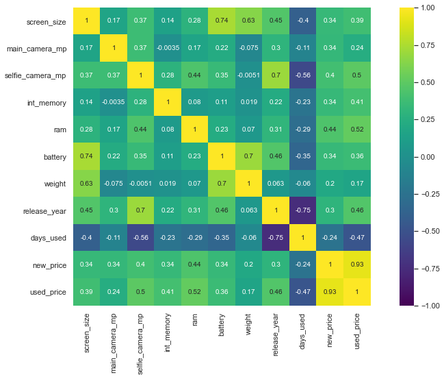

```python
## To find Correlation is lets draw Correlation matrix
numberCols = mobData.select_dtypes(include=np.number).columns.tolist()
# Bivariate analysis
mobData_corr = mobData.corr()

plt.figure(figsize=(15, 8))
sns.heatmap(mobData_corr,cmap='viridis',vmax=1.0, vmin=-1.0,
            annot=True,square=True)
plt.show()
```

### Insights

- As expected used_price has -ve corelation with days_used
- Screen size and battery has high correlation
- Weight and screen size has high correlation as well as weight and battery.
- Price values new and Used have highest correlation
- Ram and Used price also seems to have correlation

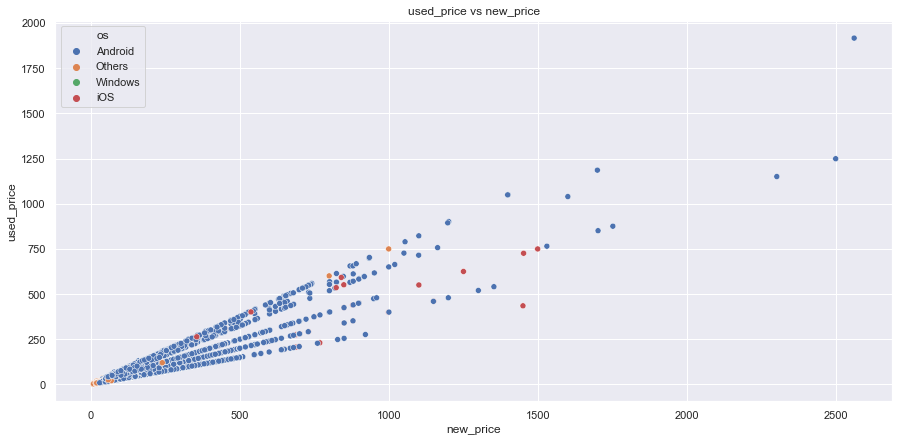

```python
 # Used price vs new prices
plt.figure(figsize=(15, 7))
sns.scatterplot(data=mobData, y="used_price", x="new_price",hue='os' )
plt.title("used_price vs new_price");
plt.show()
```

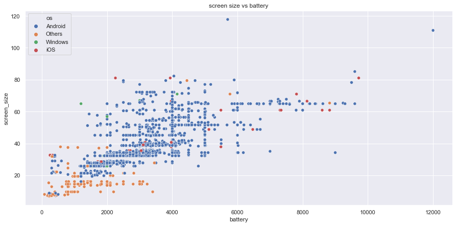

```python
 # screen size vs battery
plt.figure(figsize=(15, 7))
sns.scatterplot(data=mobData, y="screen_size", x="battery",hue='os' )
plt.title("screen size vs battery");
plt.show()
```

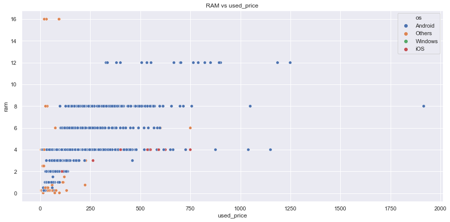

```python
 # RAM vs used price
plt.figure(figsize=(15, 7))
sns.scatterplot(data=mobData, y="ram", x="used_price",hue='os' )
plt.title("RAM vs used_price");
plt.show()
```

## Outlier Detection and Treatment

Handling outliers in the data .

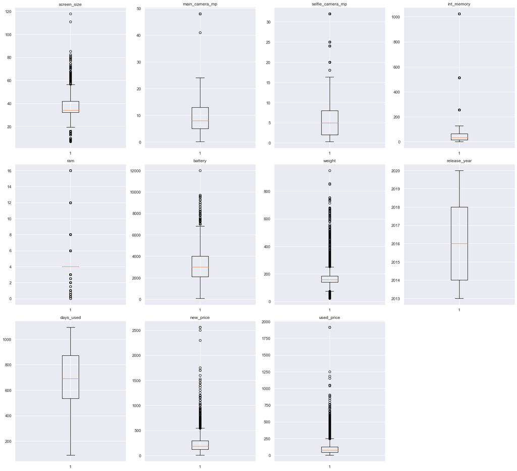

```python
# let's plot the boxplots of all columns to check for outliers
plt.figure(figsize=(20, 30))

for i, variable in enumerate(numberCols):
    plt.subplot(5, 4, i + 1)
    plt.boxplot(mobData[variable], whis=1.5)
    plt.tight_layout()
    plt.title(variable)

plt.show()
```

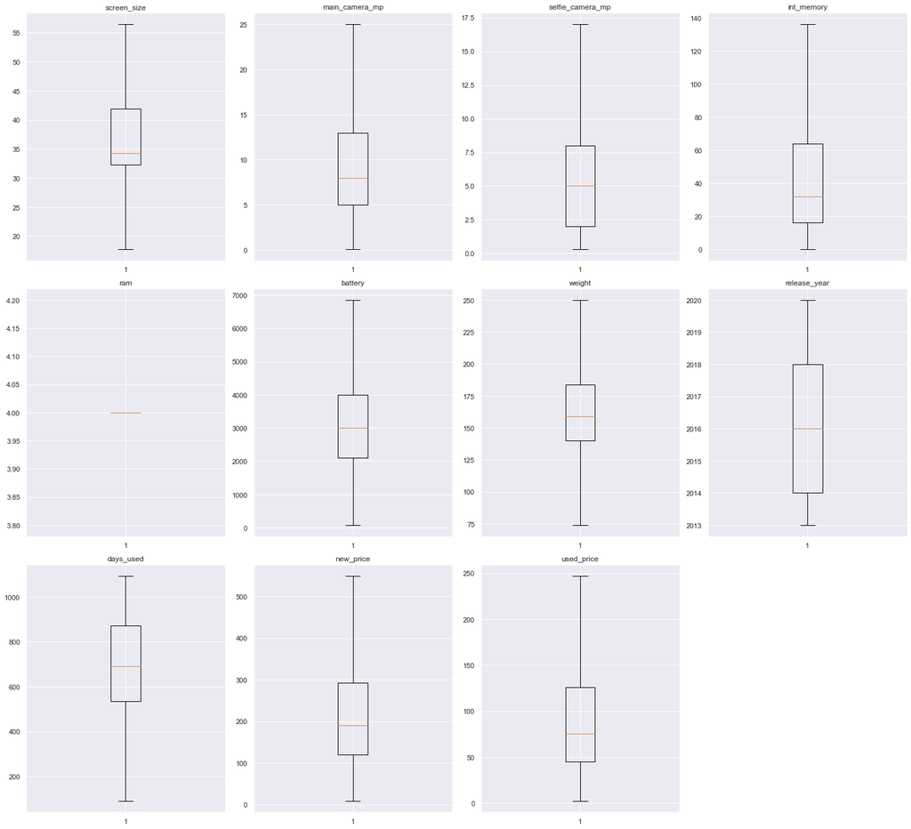

```python
def treat_outliers(df, col):
    """
    treats outliers in a variable
    col: str, name of the numerical variable
    df: dataframe
    col: name of the column
    """
    Q1 = df[col].quantile(0.25)  # 25th quantile
    Q3 = df[col].quantile(0.75)  # 75th quantile
    IQR = Q3 - Q1
    Lower_Whisker = Q1 - 1.5 * IQR
    Upper_Whisker = Q3 + 1.5 * IQR

    # all the values smaller than Lower_Whisker will be assigned the value of Lower_Whisker
    # all the values greater than Upper_Whisker will be assigned the value of Upper_Whisker
    df[col] = np.clip(df[col], Lower_Whisker, Upper_Whisker)

    return df


def treat_outliers_all(df, col_list):
    """
    treat outlier in all numerical variables
    col_list: list of numerical variables
    df: data frame
    """
    for c in col_list:
        df = treat_outliers(df, c)

    return df
# treating the outliers
numerical_col = mobData.select_dtypes(include=np.number).columns.tolist()
mobData = treat_outliers_all(mobData, numerical_col)
# let's look at the boxplots to see if the outliers have been treated or not
plt.figure(figsize=(20, 30))

for i, variable in enumerate(numberCols):
    plt.subplot(5, 4, i + 1)
    plt.boxplot(mobData[variable], whis=1.5)
    plt.tight_layout()
    plt.title(variable)

plt.show()
```

```python
mobData.describe().T
```

|  | count | mean | std | min | 25% | 50% | 75% | max |
| --- | --- | --- | --- | --- | --- | --- | --- | --- |
| screen_size | 3571.00 | 36.89 | 10.58 | 17.74 | 32.26 | 34.26 | 41.94 | 56.46 |
| main_camera_mp | 3571.00 | 9.30 | 4.53 | 0.08 | 5.00 | 8.00 | 13.00 | 25.00 |
| selfie_camera_mp | 3571.00 | 5.97 | 5.29 | 0.30 | 2.00 | 5.00 | 8.00 | 17.00 |
| int_memory | 3571.00 | 44.58 | 38.94 | 0.01 | 16.00 | 32.00 | 64.00 | 136.00 |
| ram | 3571.00 | 4.00 | 0.00 | 4.00 | 4.00 | 4.00 | 4.00 | 4.00 |
| battery | 3571.00 | 3041.13 | 1273.40 | 80.00 | 2100.00 | 3000.00 | 4000.00 | 6850.00 |
| weight | 3571.00 | 164.42 | 41.10 | 74.00 | 140.00 | 159.00 | 184.00 | 250.00 |
| release_year | 3571.00 | 2015.96 | 2.29 | 2013.00 | 2014.00 | 2016.00 | 2018.00 | 2020.00 |
| days_used | 3571.00 | 675.39 | 248.64 | 91.00 | 536.00 | 690.00 | 872.00 | 1094.00 |
| new_price | 3571.00 | 221.84 | 135.41 | 9.13 | 120.13 | 189.80 | 291.94 | 549.64 |
| used_price | 3571.00 | 95.53 | 66.15 | 2.51 | 45.20 | 75.53 | 126.00 | 247.19 |

```python
#Encoding Categorical features
X = pd.get_dummies(
    mobData,
    columns=mobData.select_dtypes(include=["object", "category"]).columns.tolist(),
    drop_first=True,
)
X.head()
```

|  | screen_size | main_camera_mp | selfie_camera_mp | int_memory | ram | battery | weight | release_year | days_used | new_price | ... | brand_name_Spice | brand_name_Vivo | brand_name_XOLO | brand_name_Xiaomi | brand_name_ZTE | os_Others | os_Windows | os_iOS | fourG_yes | fiveG_yes |
| --- | --- | --- | --- | --- | --- | --- | --- | --- | --- | --- | --- | --- | --- | --- | --- | --- | --- | --- | --- | --- | --- |
| 0 | 56.46 | 13.00 | 5.00 | 64.00 | 4.00 | 3020.00 | 146.00 | 2020 | 127 | 111.62 | ... | 0 | 0 | 0 | 0 | 0 | 0 | 0 | 0 | 1 | 0 |
| 1 | 56.46 | 13.00 | 16.00 | 128.00 | 4.00 | 4300.00 | 213.00 | 2020 | 325 | 249.39 | ... | 0 | 0 | 0 | 0 | 0 | 0 | 0 | 0 | 1 | 1 |
| 2 | 56.46 | 13.00 | 8.00 | 128.00 | 4.00 | 4200.00 | 213.00 | 2020 | 162 | 359.47 | ... | 0 | 0 | 0 | 0 | 0 | 0 | 0 | 0 | 1 | 1 |
| 3 | 56.46 | 13.00 | 8.00 | 64.00 | 4.00 | 6850.00 | 250.00 | 2020 | 345 | 278.93 | ... | 0 | 0 | 0 | 0 | 0 | 0 | 0 | 0 | 1 | 1 |
| 4 | 39.93 | 13.00 | 8.00 | 64.00 | 4.00 | 5000.00 | 185.00 | 2020 | 293 | 140.87 | ... | 0 | 0 | 0 | 0 | 0 | 0 | 0 | 0 | 1 | 0 |

5 rows × 49 columns

```python
X.info()
```

```
<class 'pandas.core.frame.DataFrame'>
RangeIndex: 3571 entries, 0 to 3570
Data columns (total 49 columns):
 #   Column                 Non-Null Count  Dtype
---  ------                 --------------  -----
 0   screen_size            3571 non-null   float64
 1   main_camera_mp         3571 non-null   float64
 2   selfie_camera_mp       3571 non-null   float64
 3   int_memory             3571 non-null   float64
 4   ram                    3571 non-null   float64
 5   battery                3571 non-null   float64
 6   weight                 3571 non-null   float64
 7   release_year           3571 non-null   int64
 8   days_used              3571 non-null   int64
 9   new_price              3571 non-null   float64
```

[output cut: 41 more lines]

```python
# defining X and y variables
X = X.drop(["used_price"], axis=1)
y = mobData["used_price"]

print(X.head())
print(y.head())
```

```
   screen_size  main_camera_mp  selfie_camera_mp  int_memory  ram  battery  \
0        56.46           13.00              5.00       64.00 4.00  3020.00
1        56.46           13.00             16.00      128.00 4.00  4300.00
2        56.46           13.00              8.00      128.00 4.00  4200.00
3        56.46           13.00              8.00       64.00 4.00  6850.00
4        39.93           13.00              8.00       64.00 4.00  5000.00

   weight  release_year  days_used  new_price  ...  brand_name_Spice  \
0  146.00          2020        127     111.62  ...                 0
1  213.00          2020        325     249.39  ...                 0
2  213.00          2020        162     359.47  ...                 0
3  250.00          2020        345     278.93  ...                 0
4  185.00          2020        293     140.87  ...                 0

   brand_name_Vivo  brand_name_XOLO  brand_name_Xiaomi  brand_name_ZTE  \
```

[output cut: 20 more lines]

```python
# splitting the data in 70:30 ratio for train to test data

x_train, x_test, y_train, y_test = train_test_split(
    X, y, test_size=0.3, random_state=42
)
```

```python
print("Number of rows in train data =", x_train.shape[0])
print("Number of rows in test data =", x_test.shape[0])
```

```
Number of rows in train data = 2499
Number of rows in test data = 1072
```

```python
# fitting the model on the train data (70% of the whole data)
from sklearn.linear_model import LinearRegression

linearregression = LinearRegression()
linearregression.fit(x_train, y_train)
```

```
LinearRegression()
```

```python
coef_df = pd.DataFrame(
    np.append(linearregression.coef_, linearregression.intercept_),
    index=x_train.columns.tolist() + ["Intercept"],
    columns=["Coefficients"],
)

coef_df
```

|  | Coefficients |
| --- | --- |
| screen_size | 0.08 |
| main_camera_mp | -0.27 |
| selfie_camera_mp | 0.84 |
| int_memory | 0.09 |
| ram | 0.00 |
| battery | 0.00 |
| weight | -0.01 |
| release_year | -0.24 |
| days_used | -0.08 |
| new_price | 0.38 |
| brand_name_Alcatel | 0.17 |
| brand_name_Apple | 23.32 |
| brand_name_Asus | 0.60 |
| brand_name_BlackBerry | 6.70 |
| brand_name_Celkon | -0.72 |
| brand_name_Coolpad | 6.62 |
| brand_name_Gionee | -5.27 |
| brand_name_Google | 12.23 |
| brand_name_HTC | -0.64 |
| brand_name_Honor | 2.07 |
| brand_name_Huawei | 0.98 |
| brand_name_Infinix | -14.83 |
| brand_name_Karbonn | -1.37 |
| brand_name_LG | 1.75 |
| brand_name_Lava | -1.31 |
| brand_name_Lenovo | -1.70 |
| brand_name_Meizu | -0.65 |
| brand_name_Micromax | 1.21 |
| brand_name_Microsoft | -3.46 |
| brand_name_Motorola | -0.76 |
| brand_name_Nokia | -7.48 |
| brand_name_OnePlus | -16.89 |
| brand_name_Oppo | -2.62 |
| brand_name_Others | 0.42 |
| brand_name_Panasonic | 1.34 |
| brand_name_Realme | -2.65 |
| brand_name_Samsung | 0.59 |
| brand_name_Sony | 1.03 |
| brand_name_Spice | 1.78 |
| brand_name_Vivo | 0.92 |
| brand_name_XOLO | 2.85 |
| brand_name_Xiaomi | -1.30 |
| brand_name_ZTE | -0.50 |
| os_Others | -4.00 |
| os_Windows | 2.51 |
| os_iOS | -15.88 |
| fourG_yes | -2.87 |
| fiveG_yes | 2.11 |
| Intercept | 549.24 |

### Let's check the performance of the model using different metrics.

- We will be using metric functions defined in sklearn for RMSE, MAE, and R2.
- We will define a function to calculate MAPE and adjusted R2.

*The mean absolute percentage error (MAPE) measures the accuracy of predictions as a percentage, and can be calculated as the average absolute percent error for each predicted value minus actual values divided by actual values. It works best if there are no extreme values in the data and none of the actual values are 0.*We will create a function which will print out all the above metrics in one go.

```python
# function to compute adjusted R-squared
def adj_r2_score(predictors, targets, predictions):
    r2 = r2_score(targets, predictions)
    n = predictors.shape[0]
    k = predictors.shape[1]
    return 1 - ((1 - r2) * (n - 1) / (n - k - 1))


# function to compute MAPE
def mape_score(targets, predictions):
    return np.mean(np.abs(targets - predictions) / targets) * 100


# function to compute different metrics to check performance of a regression model
def model_performance_regression(model, predictors, target):
    """
    Function to compute different metrics to check regression model performance

    model: regressor
    predictors: independent variables
    target: dependent variable
    """

    # predicting using the independent variables
    pred = model.predict(predictors)

    r2 = r2_score(target, pred)  # to compute R-squared
    adjr2 = adj_r2_score(predictors, target, pred)  # to compute adjusted R-squared
    rmse = np.sqrt(mean_squared_error(target, pred))  # to compute RMSE
    mae = mean_absolute_error(target, pred)  # to compute MAE
    mape = mape_score(target, pred)  # to compute MAPE

    # creating a dataframe of metrics
    df_perf = pd.DataFrame(
        {
            "RMSE": rmse,
            "MAE": mae,
            "R-squared": r2,
            "Adj. R-squared": adjr2,
            "MAPE": mape,
        },
        index=[0],
    )

    return df_perf
```

```python
# checking model performance on train set (seen 70% data)
print("Training Performance\n")
linearregression_train_perf = model_performance_regression(
    linearregression, x_train, y_train
)
linearregression_train_perf
```

```
Training Performance
```

|  | RMSE | MAE | R-squared | Adj. R-squared | MAPE |
| --- | --- | --- | --- | --- | --- |
| 0 | 13.96 | 10.22 | 0.96 | 0.95 | 18.49 |

```python
# checking model performance on test set (seen 30% data)
print("Test Performance\n")
linearregression_test_perf = model_performance_regression(
    linearregression, x_test, y_test
)
linearregression_test_perf
```

```
Test Performance
```

|  | RMSE | MAE | R-squared | Adj. R-squared | MAPE |
| --- | --- | --- | --- | --- | --- |
| 0 | 13.75 | 10.17 | 0.96 | 0.96 | 16.42 |

## Observations

The training 𝑅2 is 96%, indicating that the model explains 96% of the variation in the train data. So, the model is not underfitting.

MAE and RMSE on the train and test sets are comparable, which shows that the model is not overfitting.

MAE indicates that our current model is able to predict used phone prices within a mean error of ~10 currency units on the test data.

MAPE on the test set suggests we can predict within ~16.42% of the used phone prices.

### Linear Regression using statsmodels

Let's build a linear regression model using statsmodels.

```python
import statsmodels.api as sm
# unlike sklearn, statsmodels does not add a constant to the data on its own
# we have to add the constant manually
x_train1 = sm.add_constant(x_train)
# adding constant to the test data
x_test1 = sm.add_constant(x_test)

olsmod0 = sm.OLS(y_train, x_train1).fit()
print(olsmod0.summary())
```

```
                            OLS Regression Results
==============================================================================
Dep. Variable:             used_price   R-squared:                       0.955
Model:                            OLS   Adj. R-squared:                  0.954
Method:                 Least Squares   F-statistic:                     1110.
Date:                Fri, 01 Oct 2021   Prob (F-statistic):               0.00
Time:                        23:59:57   Log-Likelihood:                -10134.
No. Observations:                2499   AIC:                         2.036e+04
Df Residuals:                    2451   BIC:                         2.064e+04
Df Model:                          47
Covariance Type:            nonrobust
=========================================================================================
                            coef    std err          t      P>|t|      [0.025      0.975]
-----------------------------------------------------------------------------------------
screen_size               0.0836      0.050      1.671      0.095      -0.015       0.182
main_camera_mp           -0.2738      0.092     -2.978      0.003      -0.454      -0.094
selfie_camera_mp          0.8375      0.105      8.003      0.000       0.632       1.043
int_memory                0.0859      0.011      8.001      0.000       0.065       0.107
ram                     137.3093    138.231      0.993      0.321    -133.753     408.371
battery                8.297e-05      0.000      0.191      0.849      -0.001       0.001
weight                   -0.0115      0.012     -0.929      0.353      -0.036       0.013
release_year             -0.2418      0.274     -0.882      0.378      -0.780       0.296
days_used                -0.0846      0.002    -46.371      0.000      -0.088      -0.081
new_price                 0.3845      0.003    111.683      0.000       0.378       0.391
brand_name_Alcatel        0.1730      2.956      0.059      0.953      -5.623       5.969
brand_name_Apple         23.3181     10.523      2.216      0.027       2.683      43.953
brand_name_Asus           0.5951      2.945      0.202      0.840      -5.179       6.370
brand_name_BlackBerry     6.7033      4.641      1.444      0.149      -2.398      15.804
brand_name_Celkon        -0.7228      3.855     -0.187      0.851      -8.283       6.837
brand_name_Coolpad        6.6162      4.571      1.448      0.148      -2.346      15.579
brand_name_Gionee        -5.2681      3.405     -1.547      0.122     -11.945       1.408
brand_name_Google        12.2319      4.860      2.517      0.012       2.702      21.762
brand_name_HTC           -0.6402      3.000     -0.213      0.831      -6.524       5.243
brand_name_Honor          2.0733      3.021      0.686      0.493      -3.850       7.997
brand_name_Huawei         0.9782      2.762      0.354      0.723      -4.438       6.394
brand_name_Infinix      -14.8339      6.366     -2.330      0.020     -27.317      -2.351
brand_name_Karbonn       -1.3654      3.880     -0.352      0.725      -8.974       6.243
brand_name_LG             1.7502      2.778      0.630      0.529      -3.698       7.198
brand_name_Lava          -1.3144      3.711     -0.354      0.723      -8.591       5.963
brand_name_Lenovo        -1.7041      2.849     -0.598      0.550      -7.291       3.883
```

[output cut: 18 more lines]

```
os_Windows                2.5132      2.718      0.925      0.355      -2.816       7.843
os_iOS                  -15.8762     10.454     -1.519      0.129     -36.377       4.624
fourG_yes                -2.8687      0.914     -3.138      0.002      -4.661      -1.076
fiveG_yes                 2.1148      1.723      1.227      0.220      -1.264       5.494
==============================================================================
Omnibus:                      288.240   Durbin-Watson:                   1.983
Prob(Omnibus):                  0.000   Jarque-Bera (JB):              654.498
Skew:                           0.685   Prob(JB):                    7.54e-143
Kurtosis:                       5.100   Cond. No.                     1.88e+06
==============================================================================

Notes:
[1] Standard Errors assume that the covariance matrix of the errors is correctly specified.
[2] The condition number is large, 1.88e+06. This might indicate that there are
strong multicollinearity or other numerical problems.
```

Observations

- Negative values of the coefficient show that used_price decreases with the increase of corresponding attribute value.
- Positive values of the coefficient show that used_price increases with the increase of corresponding attribute value.
- p-value of a variable indicates if the variable is significant or not. If we consider the significance level to be 0.05 (5%), then any variable with a p-value less than 0.05 would be considered significant.
- But these variables might contain multicollinearity, which will affect the p-values.
- So, we need to deal with multicollinearity and check the other assumptions of linear regression first, and then look at the p-values.

## Checking Linear Regression Assumptions

#### We will be checking the following Linear Regression assumptions:

1. No Multicollinearity
2. Linearity of variables
3. Independence of error terms
4. Normality of error terms
5. No Heteroscedasticity

#### TEST FOR MULTICOLLINEARITY

- Multicollinearity occurs when predictor variables in a regression model are correlated. This correlation is a problem because predictor variables should be independent. If the correlation between variables is high, it can cause problems when we fit the model and interpret the results. When we have multicollinearity in the linear model, the coefficients that the model suggests are unreliable.
- There are different ways of detecting (or testing) multicollinearity. One such way is by using the Variance Inflation Factor, or VIF.
- #Variance Inflation Factor (VIF)#: Variance inflation factors measure the inflation in the variances of the regression parameter estimates due to collinearities that exist among the predictors. It is a measure of how much the variance of the estimated regression coefficient βk is "inflated" by the existence of correlation among the predictor variables in the model.

If VIF is 1, then there is no correlation among the kth predictor and the remaining predictor variables, and hence, the variance of βk is not inflated at all. General Rule of thumb:

- If VIF is between 1 and 5, then there is low multicollinearity.
- If VIF is between 5 and 10, we say there is moderate multicollinearity.
- If VIF is exceeding 10, it shows signs of high multicollinearity.

```python
from statsmodels.stats.outliers_influence import variance_inflation_factor

# we will define a function to check VIF
def checking_vif(predictors):
    vif = pd.DataFrame()
    vif["feature"] = predictors.columns

    # calculating VIF for each feature
    vif["VIF"] = [
        variance_inflation_factor(predictors.values, i)
        for i in range(len(predictors.columns))
    ]
    return vif
```

```python
checking_vif(x_train1)
```

|  | feature | VIF |
| --- | --- | --- |
| 0 | screen_size | 3.53 |
| 1 | main_camera_mp | 2.23 |
| 2 | selfie_camera_mp | 3.86 |
| 3 | int_memory | 2.19 |
| 4 | ram | 3844748.03 |
| 5 | battery | 3.75 |
| 6 | weight | 3.21 |
| 7 | release_year | 5.00 |
| 8 | days_used | 2.63 |
| 9 | new_price | 2.71 |
| 10 | brand_name_Alcatel | 3.49 |
| 11 | brand_name_Apple | 21.39 |
| 12 | brand_name_Asus | 3.62 |
| 13 | brand_name_BlackBerry | 1.51 |
| 14 | brand_name_Celkon | 2.00 |
| 15 | brand_name_Coolpad | 1.46 |
| 16 | brand_name_Gionee | 2.18 |
| 17 | brand_name_Google | 1.42 |
| 18 | brand_name_HTC | 3.42 |
| 19 | brand_name_Honor | 3.73 |
| 20 | brand_name_Huawei | 6.48 |
| 21 | brand_name_Infinix | 1.22 |
| 22 | brand_name_Karbonn | 1.73 |
| 23 | brand_name_LG | 5.61 |
| 24 | brand_name_Lava | 1.85 |
| 25 | brand_name_Lenovo | 4.41 |
| 26 | brand_name_Meizu | 2.41 |
| 27 | brand_name_Micromax | 3.55 |
| 28 | brand_name_Microsoft | 2.08 |
| 29 | brand_name_Motorola | 3.83 |
| 30 | brand_name_Nokia | 3.95 |
| 31 | brand_name_OnePlus | 1.62 |
| 32 | brand_name_Oppo | 4.09 |
| 33 | brand_name_Others | 10.55 |
| 34 | brand_name_Panasonic | 2.11 |
| 35 | brand_name_Realme | 1.85 |
| 36 | brand_name_Samsung | 8.46 |
| 37 | brand_name_Sony | 2.90 |
| 38 | brand_name_Spice | 1.63 |
| 39 | brand_name_Vivo | 3.50 |
| 40 | brand_name_XOLO | 2.12 |
| 41 | brand_name_Xiaomi | 4.17 |
| 42 | brand_name_ZTE | 3.58 |
| 43 | os_Others | 1.63 |
| 44 | os_Windows | 1.75 |
| 45 | os_iOS | 20.05 |
| 46 | fourG_yes | 2.38 |
| 47 | fiveG_yes | 1.48 |

- Os_iOS, various brand names have high VIF values

### Removing Multicollinearity

To remove multicollinearity

1. Drop every column one by one that has a VIF score greater than 5.
2. Look at the adjusted R-squared and RMSE of all these models.
3. Drop the variable that makes the least change in adjusted R-squared.
4. Check the VIF scores again.
5. Continue till you get all VIF scores under 5.

Let's define a function that will help us do this.

```python
def treating_multicollinearity(predictors, target, high_vif_columns):
    """
    Checking the effect of dropping the columns showing high multicollinearity
    on model performance (adj. R-squared and RMSE)

    predictors: independent variables
    target: dependent variable
    high_vif_columns: columns having high VIF
    """
    # empty lists to store adj. R-squared and RMSE values
    adj_r2 = []
    rmse = []

    # build ols models by dropping one of the high VIF columns at a time
    # store the adjusted R-squared and RMSE in the lists defined previously
    for cols in high_vif_columns:
        # defining the new train set
        train = predictors.loc[:, ~predictors.columns.str.startswith(cols)]

        # create the model
        olsmodel = sm.OLS(target, train).fit()

        # adding adj. R-squared and RMSE to the lists
        adj_r2.append(olsmodel.rsquared_adj)
        rmse.append(np.sqrt(olsmodel.mse_resid))

    # creating a dataframe for the results
    temp = pd.DataFrame(
        {
            "col": high_vif_columns,
            "Adj. R-squared after_dropping col": adj_r2,
            "RMSE after dropping col": rmse,
        }
    ).sort_values(by="Adj. R-squared after_dropping col", ascending=False)
    temp.reset_index(drop=True, inplace=True)

    return temp
```

```python
col_list = ['os_iOS','brand_name_Samsung','brand_name_Apple' , 'release_year' ]

res = treating_multicollinearity(x_train1, y_train, col_list)
res
```

|  | col | Adj. R-squared after_dropping col | RMSE after dropping col |
| --- | --- | --- | --- |
| 0 | brand_name_Samsung | 0.95 | 14.09 |
| 1 | release_year | 0.95 | 14.10 |
| 2 | os_iOS | 0.95 | 14.10 |
| 3 | brand_name_Apple | 0.95 | 14.11 |

check the model performance

```python
# checking VIF after dropping columns having p>0.05
col_to_drop ='os_iOS','brand_name_Samsung','brand_name_Apple' , 'release_year'
x_train2 = x_train1.loc[:, ~x_train1.columns.str.startswith(col_to_drop)]
x_test2 = x_test1.loc[:, ~x_test1.columns.str.startswith(col_to_drop)]

# Check VIF now
vif = checking_vif(x_train2)
print("VIF after dropping ", col_to_drop)
vif
```

```
VIF after dropping  ('os_iOS', 'brand_name_Samsung', 'brand_name_Apple', 'release_year')
```

|  | feature | VIF |
| --- | --- | --- |
| 0 | screen_size | 3.47 |
| 1 | main_camera_mp | 2.21 |
| 2 | selfie_camera_mp | 3.12 |
| 3 | int_memory | 2.17 |
| 4 | ram | 66.52 |
| 5 | battery | 3.68 |
| 6 | weight | 3.13 |
| 7 | days_used | 1.96 |
| 8 | new_price | 2.40 |
| 9 | brand_name_Alcatel | 1.27 |
| 10 | brand_name_Asus | 1.26 |
| 11 | brand_name_BlackBerry | 1.08 |
| 12 | brand_name_Celkon | 1.26 |
| 13 | brand_name_Coolpad | 1.06 |
| 14 | brand_name_Gionee | 1.11 |
| 15 | brand_name_Google | 1.04 |
| 16 | brand_name_HTC | 1.23 |
| 17 | brand_name_Honor | 1.39 |
| 18 | brand_name_Huawei | 1.57 |
| 19 | brand_name_Infinix | 1.05 |
| 20 | brand_name_Karbonn | 1.11 |
| 21 | brand_name_LG | 1.41 |
| 22 | brand_name_Lava | 1.13 |
| 23 | brand_name_Lenovo | 1.36 |
| 24 | brand_name_Meizu | 1.16 |
| 25 | brand_name_Micromax | 1.32 |
| 26 | brand_name_Microsoft | 1.65 |
| 27 | brand_name_Motorola | 1.35 |
| 28 | brand_name_Nokia | 1.50 |
| 29 | brand_name_OnePlus | 1.11 |
| 30 | brand_name_Oppo | 1.36 |
| 31 | brand_name_Others | 1.94 |
| 32 | brand_name_Panasonic | 1.12 |
| 33 | brand_name_Realme | 1.14 |
| 34 | brand_name_Sony | 1.22 |
| 35 | brand_name_Spice | 1.10 |
| 36 | brand_name_Vivo | 1.33 |
| 37 | brand_name_XOLO | 1.16 |
| 38 | brand_name_Xiaomi | 1.43 |
| 39 | brand_name_ZTE | 1.27 |
| 40 | os_Others | 1.58 |
| 41 | os_Windows | 1.74 |
| 42 | fourG_yes | 2.11 |
| 43 | fiveG_yes | 1.45 |

```python
# fitting model again after dropping required variables
olsmod1 = sm.OLS(y_train, x_train2).fit()
print(olsmod1.summary())
```

```
                            OLS Regression Results
==============================================================================
Dep. Variable:             used_price   R-squared:                       0.955
Model:                            OLS   Adj. R-squared:                  0.954
Method:                 Least Squares   F-statistic:                     1209.
Date:                Fri, 01 Oct 2021   Prob (F-statistic):               0.00
Time:                        23:59:58   Log-Likelihood:                -10140.
No. Observations:                2499   AIC:                         2.037e+04
Df Residuals:                    2455   BIC:                         2.062e+04
Df Model:                          43
Covariance Type:            nonrobust
=========================================================================================
                            coef    std err          t      P>|t|      [0.025      0.975]
-----------------------------------------------------------------------------------------
screen_size               0.0867      0.050      1.744      0.081      -0.011       0.184
main_camera_mp           -0.2881      0.092     -3.141      0.002      -0.468      -0.108
selfie_camera_mp          0.7696      0.094      8.161      0.000       0.585       0.954
int_memory                0.0842      0.011      7.867      0.000       0.063       0.105
ram                      15.7575      0.576     27.360      0.000      14.628      16.887
battery                   0.0001      0.000      0.260      0.795      -0.001       0.001
weight                   -0.0150      0.012     -1.222      0.222      -0.039       0.009
days_used                -0.0841      0.002    -53.326      0.000      -0.087      -0.081
new_price                 0.3876      0.003    119.542      0.000       0.381       0.394
brand_name_Alcatel       -0.9831      1.787     -0.550      0.582      -4.486       2.520
brand_name_Asus          -0.6131      1.737     -0.353      0.724      -4.020       2.793
brand_name_BlackBerry     5.5227      3.931      1.405      0.160      -2.186      13.231
brand_name_Celkon        -1.5043      3.068     -0.490      0.624      -7.521       4.513
brand_name_Coolpad        5.5317      3.894      1.420      0.156      -2.105      13.168
brand_name_Gionee        -6.4560      2.437     -2.649      0.008     -11.234      -1.678
brand_name_Google        10.2432      4.176      2.453      0.014       2.054      18.432
brand_name_HTC           -1.7662      1.799     -0.982      0.326      -5.293       1.761
brand_name_Honor          0.9127      1.851      0.493      0.622      -2.716       4.542
brand_name_Huawei        -0.2427      1.361     -0.178      0.859      -2.912       2.427
brand_name_Infinix      -16.1428      5.904     -2.734      0.006     -27.720      -4.566
brand_name_Karbonn       -2.2080      3.121     -0.708      0.479      -8.327       3.911
brand_name_LG             0.4633      1.394      0.332      0.740      -2.269       3.196
brand_name_Lava          -2.2965      2.898     -0.792      0.428      -7.979       3.386
brand_name_Lenovo        -2.7857      1.586     -1.757      0.079      -5.895       0.323
brand_name_Meizu         -1.8239      2.339     -0.780      0.436      -6.410       2.763
brand_name_Micromax       0.1863      1.798      0.104      0.917      -3.340       3.713
```

[output cut: 14 more lines]

```
os_Others                -3.7213      1.485     -2.506      0.012      -6.633      -0.810
os_Windows                2.4984      2.712      0.921      0.357      -2.820       7.817
fourG_yes                -3.1112      0.864     -3.602      0.000      -4.805      -1.418
fiveG_yes                 1.5015      1.712      0.877      0.380      -1.855       4.858
==============================================================================
Omnibus:                      297.890   Durbin-Watson:                   1.984
Prob(Omnibus):                  0.000   Jarque-Bera (JB):              688.667
Skew:                           0.699   Prob(JB):                    2.87e-150
Kurtosis:                       5.158   Cond. No.                     7.14e+04
==============================================================================

Notes:
[1] Standard Errors assume that the covariance matrix of the errors is correctly specified.
[2] The condition number is large, 7.14e+04. This might indicate that there are
strong multicollinearity or other numerical problems.
```

```python
# check Adjusted R^2 and RMSE after dropping variables with p>0.05
col_list = ['fiveG_yes','os_Windows','battery' ,'weight','screen_size','brand_name_ZTE',
            'brand_name_Xiaomi','brand_name_XOLO','brand_name_Vivo','brand_name_Spice','brand_name_Sony',
            'brand_name_Realme','brand_name_Panasonic','brand_name_Others','brand_name_Oppo','brand_name_OnePlus',
           'brand_name_Nokia','brand_name_Motorola','brand_name_Microsoft','brand_name_Micromax','brand_name_Meizu',
           'brand_name_Lenovo','brand_name_Lava','brand_name_LG','brand_name_Huawei','brand_name_Honor',
           'brand_name_HTC','brand_name_Google','brand_name_Gionee','brand_name_Coolpad','brand_name_Celkon',
           'brand_name_BlackBerry','brand_name_Asus','brand_name_Alcatel','brand_name_Infinix','brand_name_Karbonn']

result = treating_multicollinearity(x_train2, y_train, col_list)
result
```

|  | col | Adj. R-squared after_dropping col | RMSE after dropping col |
| --- | --- | --- | --- |
| 0 | brand_name_Sony | 0.95 | 14.12 |
| 1 | brand_name_Panasonic | 0.95 | 14.12 |
| 2 | brand_name_Micromax | 0.95 | 14.12 |
| 3 | brand_name_Vivo | 0.95 | 14.12 |
| 4 | brand_name_Huawei | 0.95 | 14.12 |
| 5 | battery | 0.95 | 14.12 |
| 6 | brand_name_Spice | 0.95 | 14.12 |
| 7 | brand_name_LG | 0.95 | 14.12 |
| 8 | brand_name_Asus | 0.95 | 14.12 |
| 9 | brand_name_Celkon | 0.95 | 14.12 |
| 10 | brand_name_Honor | 0.95 | 14.12 |
| 11 | brand_name_Alcatel | 0.95 | 14.12 |
| 12 | brand_name_Others | 0.95 | 14.12 |
| 13 | brand_name_Karbonn | 0.95 | 14.12 |
| 14 | brand_name_XOLO | 0.95 | 14.12 |
| 15 | brand_name_Meizu | 0.95 | 14.12 |
| 16 | brand_name_Lava | 0.95 | 14.12 |
| 17 | fiveG_yes | 0.95 | 14.12 |
| 18 | os_Windows | 0.95 | 14.12 |
| 19 | brand_name_ZTE | 0.95 | 14.12 |
| 20 | brand_name_HTC | 0.95 | 14.12 |
| 21 | brand_name_Microsoft | 0.95 | 14.12 |
| 22 | brand_name_Motorola | 0.95 | 14.12 |
| 23 | weight | 0.95 | 14.12 |
| 24 | brand_name_Realme | 0.95 | 14.12 |
| 25 | brand_name_Xiaomi | 0.95 | 14.12 |
| 26 | brand_name_BlackBerry | 0.95 | 14.12 |
| 27 | brand_name_Coolpad | 0.95 | 14.12 |
| 28 | screen_size | 0.95 | 14.13 |
| 29 | brand_name_Lenovo | 0.95 | 14.13 |
| 30 | brand_name_Oppo | 0.95 | 14.13 |
| 31 | brand_name_Google | 0.95 | 14.13 |
| 32 | brand_name_Gionee | 0.95 | 14.14 |
| 33 | brand_name_Infinix | 0.95 | 14.14 |
| 34 | brand_name_Nokia | 0.95 | 14.18 |
| 35 | brand_name_OnePlus | 0.95 | 14.19 |

Let's check the model performance.

```python
# check Adjusted R^2 and RMSE after dropping variables
col_lists = 'fiveG_yes','os_Windows','battery' ,'weight','screen_size','brand_name_Infinix','brand_name_Karbonn','brand_name_ZTE','brand_name_Xiaomi','brand_name_XOLO','brand_name_Vivo','brand_name_Spice','brand_name_Sony','brand_name_Realme','brand_name_Panasonic','brand_name_Others','brand_name_Oppo','brand_name_OnePlus','brand_name_Nokia','brand_name_Motorola','brand_name_Microsoft','brand_name_Micromax','brand_name_Meizu','brand_name_Lenovo','brand_name_Lava','brand_name_LG','brand_name_Huawei','brand_name_Honor','brand_name_HTC','brand_name_Google','brand_name_Gionee','brand_name_Coolpad','brand_name_Celkon','brand_name_BlackBerry','brand_name_Asus','brand_name_Alcatel'
x_train3 = x_train2.loc[:, ~x_train2.columns.str.startswith(col_lists)]
x_test3 = x_test2.loc[:, ~x_test2.columns.str.startswith(col_lists)]

# Check VIF now
vif = checking_vif(x_train3)
print("VIF after dropping ", col_lists)
vif
```

```
VIF after dropping  ('fiveG_yes', 'os_Windows', 'battery', 'weight', 'screen_size', 'brand_name_Infinix', 'brand_name_Karbonn', 'brand_name_ZTE', 'brand_name_Xiaomi', 'brand_name_XOLO', 'brand_name_Vivo', 'brand_name_Spice', 'brand_name_Sony', 'brand_name_Realme', 'brand_name_Panasonic', 'brand_name…
```

|  | feature | VIF |
| --- | --- | --- |
| 0 | main_camera_mp | 1.77 |
| 1 | selfie_camera_mp | 2.72 |
| 2 | int_memory | 1.86 |
| 3 | ram | 23.98 |
| 4 | days_used | 1.66 |
| 5 | new_price | 1.64 |
| 6 | os_Others | 1.14 |
| 7 | fourG_yes | 1.79 |

```python
olsmod2 = sm.OLS(y_train, x_train3).fit()
print(olsmod2.summary())
```

```
                            OLS Regression Results
==============================================================================
Dep. Variable:             used_price   R-squared:                       0.953
Model:                            OLS   Adj. R-squared:                  0.953
Method:                 Least Squares   F-statistic:                     7249.
Date:                Fri, 01 Oct 2021   Prob (F-statistic):               0.00
Time:                        23:59:58   Log-Likelihood:                -10187.
No. Observations:                2499   AIC:                         2.039e+04
Df Residuals:                    2491   BIC:                         2.044e+04
Df Model:                           7
Covariance Type:            nonrobust
====================================================================================
                       coef    std err          t      P>|t|      [0.025      0.975]
------------------------------------------------------------------------------------
main_camera_mp      -0.2151      0.083     -2.595      0.010      -0.378      -0.053
selfie_camera_mp     0.7098      0.089      7.977      0.000       0.535       0.884
int_memory           0.0836      0.010      8.338      0.000       0.064       0.103
ram                 15.7866      0.350     45.137      0.000      15.101      16.472
days_used           -0.0852      0.001    -57.984      0.000      -0.088      -0.082
new_price            0.3893      0.003    143.389      0.000       0.384       0.395
os_Others           -5.4306      1.275     -4.260      0.000      -7.931      -2.931
fourG_yes           -3.1606      0.805     -3.927      0.000      -4.739      -1.582
==============================================================================
Omnibus:                      290.917   Durbin-Watson:                   1.970
Prob(Omnibus):                  0.000   Jarque-Bera (JB):              653.702
Skew:                           0.694   Prob(JB):                    1.12e-142
Kurtosis:                       5.086   Cond. No.                     3.36e+03
==============================================================================

Notes:
[1] Standard Errors assume that the covariance matrix of the errors is correctly specified.
[2] The condition number is large, 3.36e+03. This might indicate that there are
strong multicollinearity or other numerical problems.
```

```python
# initial list of columns
cols = x_train3.columns.tolist()

# setting an initial max p-value
max_p_value = 1

while len(cols) > 0:
    # defining the train set
    x_train_aux = x_train3[cols]

    # fitting the model
    model = sm.OLS(y_train, x_train_aux).fit()

    # getting the p-values and the maximum p-value
    p_values = model.pvalues
    max_p_value = max(p_values)

    # name of the variable with maximum p-value
    feature_with_p_max = p_values.idxmax()

    if max_p_value > 0.05:
        cols.remove(feature_with_p_max)
    else:
        break

selected_features = cols
print(selected_features)
```

```
['main_camera_mp', 'selfie_camera_mp', 'int_memory', 'ram', 'days_used', 'new_price', 'os_Others', 'fourG_yes']
```

```python
# train data with only selected columns
x_train4 = x_train3[selected_features]
x_test4 = x_test3[selected_features]
```

**Now no feature has p-value greater than 0.05, so we'll consider the features in *x_train4* as the final ones and *olsmod2* as final model.**

**Observations**

- Now adjusted R-squared is 0.953, i.e., our model is able to explain ~95% of the variance. This shows that the model is good.
- The adjusted R-squared in *olsmod0* (where we considered all the variables) was 0.954. This shows that the variables we dropped were not affecting the model much.

Now we'll check the rest of the assumptions on olsmod2.

Linearity of variables

Independence of error terms

Normality of error terms

No Heteroscedasticity

### TEST FOR LINEARITY AND INDEPENDENCE

Why the test?

- Linearity describes a straight-line relationship between two variables, predictor variables must have a linear relation with the dependent variable.
- The independence of the error terms (or residuals) is important. If the residuals are not independent, then the confidence intervals of the coefficient estimates will be narrower and make us incorrectly conclude a parameter to be statistically significant.
- How to check linearity and independence?
- Make a plot of fitted values vs residuals.
- If they don't follow any pattern, then we say the model is linear and residuals are independent.
- Otherwise, the model is showing signs of non-linearity and residuals are not independent.
- How to fix if this assumption is not followed?
- We can try to transform the variables and make the relationships linear.

```python
# let us create a dataframe with actual, fitted and residual values
df_pred = pd.DataFrame()

df_pred["Actual Values"] = y_train  # actual values
df_pred["Fitted Values"] = olsmod2.fittedvalues  # predicted values
df_pred["Residuals"] = olsmod2.resid  # residuals

df_pred.head()
```

|  | Actual Values | Fitted Values | Residuals |
| --- | --- | --- | --- |
| 844 | 100.48 | 99.74 | 0.74 |
| 1539 | 111.68 | 117.18 | -5.50 |
| 3452 | 113.89 | 111.38 | 2.51 |
| 1727 | 64.09 | 70.54 | -6.45 |
| 1926 | 67.95 | 68.20 | -0.25 |

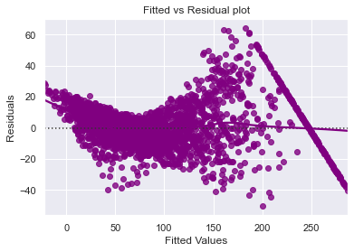

```python
# let's plot the fitted values vs residuals

sns.residplot(
    data=df_pred, x="Fitted Values", y="Residuals", color="purple", lowess=True
)
plt.xlabel("Fitted Values")
plt.ylabel("Residuals")
plt.title("Fitted vs Residual plot")
plt.show()
```

### TEST FOR NORMALITY

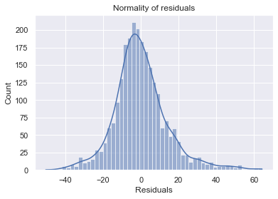

```python
sns.histplot(data=df_pred, x="Residuals", kde=True)
plt.title("Normality of residuals")
plt.show()
```

- The histogram of residuals does have a bell shape.
- Let's check the Q-Q plot.

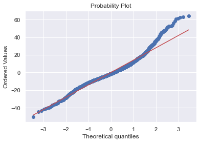

```python
import pylab
import scipy.stats as stats

stats.probplot(df_pred["Residuals"], dist="norm", plot=pylab)
plt.show()
```

- The residuals more or less follow a straight line except for the upper tail. Let's check the results of the Shapiro-Wilk test

```python
stats.shapiro(df_pred["Residuals"])
```

```
ShapiroResult(statistic=0.9608901143074036, pvalue=1.9348117786229258e-25)
```

- Since p-value < 0.05, the residuals are not normal as per the Shapiro-Wilk test.
- Strictly speaking, the residuals are not normal.
- However, as an approximation, we can accept this distribution as close to being normal.
- **So, the assumption is satisfied.**

### TEST FOR HOMOSCEDASTICITY

- Testing Homoscedasticity using goldfeldquandt test

```python
import statsmodels.stats.api as sms
from statsmodels.compat import lzip

name = ["F statistic", "p-value"]
test = sms.het_goldfeldquandt(df_pred["Residuals"], x_train4)
lzip(name, test)
```

```
[('F statistic', 1.0570907089704333), ('p-value', 0.16406630135689543)]
```

#### Since p-value > 0.05, we can say that the residuals are homoscedastic. So, this assumption is satisfied.

```python
# predictions on the test set
pred = olsmod2.predict(x_test4)

df_pred_test = pd.DataFrame({"Actual": y_test, "Predicted": pred})
df_pred_test.sample(25, random_state=1)
```

|  | Actual | Predicted |
| --- | --- | --- |
| 2098 | 30.52 | 22.69 |
| 278 | 195.67 | 188.04 |
| 26 | 247.19 | 224.45 |
| 2910 | 89.97 | 91.09 |
| 2631 | 69.20 | 62.19 |
| 1582 | 89.58 | 108.67 |
| 2110 | 247.19 | 270.62 |
| 3160 | 65.34 | 65.55 |
| 2817 | 115.77 | 106.77 |
| 549 | 39.29 | 48.13 |
| 1138 | 59.75 | 62.58 |
| 1602 | 94.40 | 86.39 |
| 1694 | 27.10 | 38.55 |
| 1735 | 79.78 | 81.63 |
| 1951 | 17.56 | -2.53 |
| 2086 | 49.91 | 51.33 |
| 318 | 54.49 | 65.14 |
| 1055 | 47.90 | 42.39 |
| 1459 | 46.83 | 55.75 |
| 2130 | 54.70 | 58.84 |
| 3182 | 99.91 | 111.56 |
| 259 | 161.96 | 140.68 |
| 547 | 183.52 | 184.83 |
| 2340 | 38.95 | 43.60 |
| 331 | 16.07 | 14.36 |

- We can observe here that the model has returned good enough prediction results, and the actual and predicted values are comparable.
- We can also visualize comparison result as a bar graph.
- Note: As the number of records is large, for representation purpose, we are taking a sample of 25 records only.

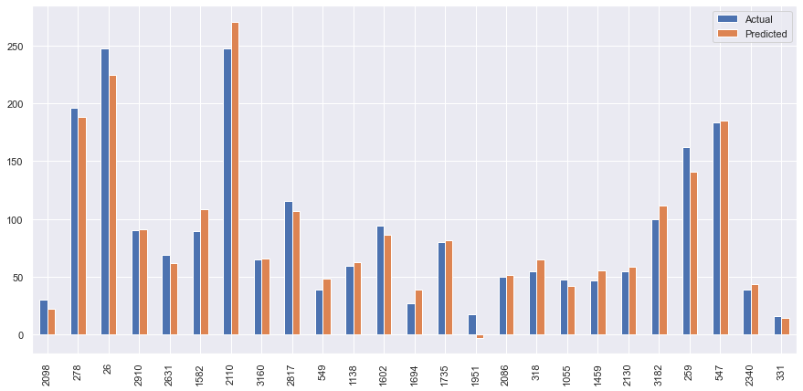

```python
df1 = df_pred_test.sample(25, random_state=1)
df1.plot(kind="bar", figsize=(15, 7))
plt.show()
```

```python
# checking model performance on train set (seen 70% data)
print("Training Performance\n")
olsmod2_train_perf = model_performance_regression(olsmod2, x_train4, y_train)
olsmod2_train_perf
```

```
Training Performance
```

|  | RMSE | MAE | R-squared | Adj. R-squared | MAPE |
| --- | --- | --- | --- | --- | --- |
| 0 | 14.26 | 10.41 | 0.95 | 0.95 | 18.81 |

```python
# checking model performance on test set (seen 30% data)
print("Test Performance\n")
olsmod2_test_perf = model_performance_regression(olsmod2, x_test4, y_test)
olsmod2_test_perf
```

```
Test Performance
```

|  | RMSE | MAE | R-squared | Adj. R-squared | MAPE |
| --- | --- | --- | --- | --- | --- |
| 0 | 13.90 | 10.18 | 0.96 | 0.96 | 16.30 |

- The model is able to explain 95% of the variation in the data, which is very good.
- The train and test RMSE and MAE are and comparable. So, our model is not suffering from overfitting.
- The MAPE on the test set suggests we can predict within 16.3% of the used phone prices.
- Hence, we can conclude the model olsmod2 is good for prediction as well as inference purposes.

Let's compare the initial model created with sklearn and the final statsmodels model.

```python
# training performance comparison

models_train_comp_df = pd.concat(
    [linearregression_train_perf.T, olsmod2_train_perf.T],
    axis=1,
)

models_train_comp_df.columns = [
    "Linear Regression sklearn",
    "Linear Regression statsmodels",
]

print("Training performance comparison:")
models_train_comp_df
```

```
Training performance comparison:
```

|  | Linear Regression sklearn | Linear Regression statsmodels |
| --- | --- | --- |
| RMSE | 13.96 | 14.26 |
| MAE | 10.22 | 10.41 |
| R-squared | 0.96 | 0.95 |
| Adj. R-squared | 0.95 | 0.95 |
| MAPE | 18.49 | 18.81 |

```python
# test performance comparison

models_test_comp_df = pd.concat(
    [linearregression_test_perf.T, olsmod2_test_perf.T],
    axis=1,
)

models_test_comp_df.columns = [
    "Linear Regression sklearn",
    "Linear Regression statsmodels",
]

print("Test performance comparison:")
models_test_comp_df
```

```
Test performance comparison:
```

|  | Linear Regression sklearn | Linear Regression statsmodels |
| --- | --- | --- |
| RMSE | 13.75 | 13.90 |
| MAE | 10.17 | 10.18 |
| R-squared | 0.96 | 0.96 |
| Adj. R-squared | 0.96 | 0.96 |
| MAPE | 16.42 | 16.30 |

- Model performances are close to each other

#### Final Model Summary

```python
olsmodel_final = sm.OLS(y_train, x_train4).fit()
print(olsmodel_final.summary())
```

```
                            OLS Regression Results
==============================================================================
Dep. Variable:             used_price   R-squared:                       0.953
Model:                            OLS   Adj. R-squared:                  0.953
Method:                 Least Squares   F-statistic:                     7249.
Date:                Sat, 02 Oct 2021   Prob (F-statistic):               0.00
Time:                        00:00:01   Log-Likelihood:                -10187.
No. Observations:                2499   AIC:                         2.039e+04
Df Residuals:                    2491   BIC:                         2.044e+04
Df Model:                           7
Covariance Type:            nonrobust
====================================================================================
                       coef    std err          t      P>|t|      [0.025      0.975]
------------------------------------------------------------------------------------
main_camera_mp      -0.2151      0.083     -2.595      0.010      -0.378      -0.053
selfie_camera_mp     0.7098      0.089      7.977      0.000       0.535       0.884
int_memory           0.0836      0.010      8.338      0.000       0.064       0.103
ram                 15.7866      0.350     45.137      0.000      15.101      16.472
days_used           -0.0852      0.001    -57.984      0.000      -0.088      -0.082
new_price            0.3893      0.003    143.389      0.000       0.384       0.395
os_Others           -5.4306      1.275     -4.260      0.000      -7.931      -2.931
fourG_yes           -3.1606      0.805     -3.927      0.000      -4.739      -1.582
==============================================================================
Omnibus:                      290.917   Durbin-Watson:                   1.970
Prob(Omnibus):                  0.000   Jarque-Bera (JB):              653.702
Skew:                           0.694   Prob(JB):                    1.12e-142
Kurtosis:                       5.086   Cond. No.                     3.36e+03
==============================================================================

Notes:
[1] Standard Errors assume that the covariance matrix of the errors is correctly specified.
[2] The condition number is large, 3.36e+03. This might indicate that there are
strong multicollinearity or other numerical problems.
```